# Prediction-Assignment-Writeup

## Introduction

Using devices such as Jawbone Up, Nike FuelBand, and Fitbit it is now possible to collect a large amount of data about personal activity relatively inexpensively. These type of devices are part of the quantified self movement – a group of enthusiasts who take measurements about themselves regularly to improve their health, to find patterns in their behavior, or because they are tech geeks. One thing that people regularly do is quantify how much of a particular activity they do, but they rarely quantify how well they do it. In this project, your goal will be to use data from accelerometers on the belt, forearm, arm, and dumbell of 6 participants. They were asked to perform barbell lifts correctly and incorrectly in 5 different ways. More information is available from the website here: http://web.archive.org/web/20161224072740/http:/groupware.les.inf.puc-rio.br/har (see the section on the Weight Lifting Exercise Dataset).

## Loading Data and Processiong

Loading package.

```r
library(knitr)
library(caret)
library(rpart)
library(randomForest)
library(e1071)
library(gbm)
```

Loading dataset.

```r
TrainUrl <- "https://d396qusza40orc.cloudfront.net/predmachlearn/pml-training.csv"
TestUrl  <- "https://d396qusza40orc.cloudfront.net/predmachlearn/pml-testing.csv"
TrainFile<-"pml-traininig.csv"
TestFile<-"pml-testing.csv"

# download the datasets
if(!file.exists(TrainFile))
{
  download.file(TrainUrl,destfile = TrainFile)
}
training <- read.csv(TrainFile)

if(!file.exists(TestFile))
{
  download.file(TestUrl,destfile = TestFile)
}
testing  <- read.csv(TestFile)
```

create a partition using caret with the training dataset on 70,30 ratio

```r
inTrain  <- createDataPartition(training$classe, p=0.7, list=FALSE)

TrainSet <- training[inTrain, ]

TestSet  <- training[-inTrain, ]

print(dim(TrainSet))
```

```
## [1] 13737   160
```

```r
print(dim(TestSet))
```

```
## [1] 5885  160
```

Look summary of TrainSet

```r
summary(TrainSet)
```

[output not shown]

[output cut: 281 more lines]

[output not shown]

Remove variables with Nearly Zero Variance.

```r
NZV <- nearZeroVar(TrainSet)
TrainSet <- TrainSet[, -NZV]
TestSet  <- TestSet[, -NZV]
dim(TestSet)
```

```
## [1] 5885  104
```

clean NA value.

```r
AllNA    <- sapply(TrainSet, function(x) mean(is.na(x))) > 0.95
TrainSet <- TrainSet[, AllNA==FALSE]
TestSet  <- TestSet[, AllNA==FALSE]
```

Delete unused columns.

```r
TrainSet <-TrainSet[,-c(1:7)]
TestSet <-TestSet[,-c(1:7)]

print(dim(TrainSet))
```

```
## [1] 13737    52
```

```r
print(dim(TestSet))
```

```
## [1] 5885   52
```

Plot Frequency of classe.

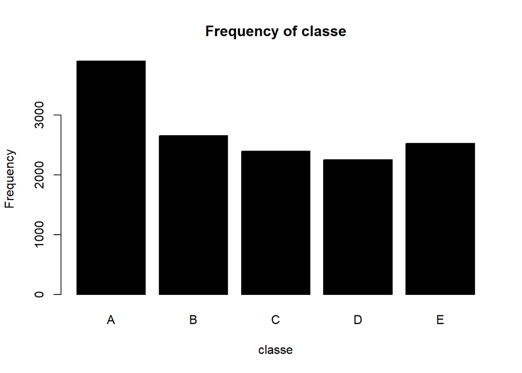

```r
plot(TrainSet$classe, col="black", main="Frequency of classe", xlab="classe", ylab="Frequency")
```

## Predction model

First, I built Random Forest Model.

```r
set.seed(0)

controlRF <- trainControl(method="cv", number=3, verboseIter=FALSE)
modFitRandForest <- train(classe ~ ., data=TrainSet, method="rf",
                          trControl=controlRF)
modFitRandForest$finalModel
```

```
##
## Call:
##  randomForest(x = x, y = y, mtry = param$mtry)
##                Type of random forest: classification
##                      Number of trees: 500
## No. of variables tried at each split: 26
##
##         OOB estimate of  error rate: 0.66%
## Confusion matrix:
##      A    B    C    D    E class.error
## A 3900    4    1    0    1 0.001536098
## B   23 2624   10    0    1 0.012791573
## C    0   13 2378    5    0 0.007512521
## D    0    0   19 2232    1 0.008880995
## E    0    1    3    8 2513 0.004752475
```

prediction on Test dataset.

```r
predictRandForest <- predict(modFitRandForest, newdata=TestSet)
confMatRandForest <- confusionMatrix(predictRandForest, TestSet$classe)
confMatRandForest
```

```
## Confusion Matrix and Statistics
##
##           Reference
## Prediction    A    B    C    D    E
##          A 1673    8    0    0    0
##          B    1 1128    4    0    0
##          C    0    2 1020    4    1
##          D    0    1    2  958    0
##          E    0    0    0    2 1081
##
## Overall Statistics
##
##                Accuracy : 0.9958
##                  95% CI : (0.9937, 0.9972)
##     No Information Rate : 0.2845
##     P-Value [Acc > NIR] : < 2.2e-16
##
##                   Kappa : 0.9946
##
##  Mcnemar's Test P-Value : NA
##
## Statistics by Class:
##
##                      Class: A Class: B Class: C Class: D Class: E
## Sensitivity            0.9994   0.9903   0.9942   0.9938   0.9991
## Specificity            0.9981   0.9989   0.9986   0.9994   0.9996
## Pos Pred Value         0.9952   0.9956   0.9932   0.9969   0.9982
## Neg Pred Value         0.9998   0.9977   0.9988   0.9988   0.9998
## Prevalence             0.2845   0.1935   0.1743   0.1638   0.1839
## Detection Rate         0.2843   0.1917   0.1733   0.1628   0.1837
## Detection Prevalence   0.2856   0.1925   0.1745   0.1633   0.1840
## Balanced Accuracy      0.9988   0.9946   0.9964   0.9966   0.9993
```

plot results with matrix.

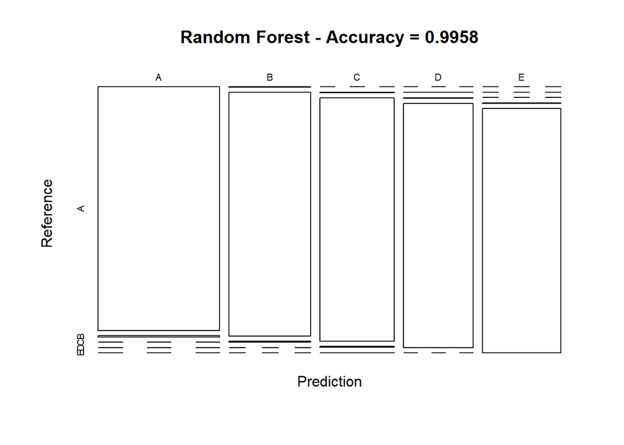

```r
plot(confMatRandForest$table, col = confMatRandForest$byClass,
     main = paste("Random Forest - Accuracy =",
                  round(confMatRandForest$overall['Accuracy'], 4)))
```

Second, I built Generalized Boosted Model (GBM)

```r
set.seed(0)
controlGBM <- trainControl(method = "repeatedcv", number = 5, repeats = 1)
modFitGBM  <- train(classe ~ ., data=TrainSet, method = "gbm",
                    trControl = controlGBM, verbose = FALSE)
```

prediction on Test dataset.

```r
predictGBM <- predict(modFitGBM, newdata=TestSet)
confMatGBM <- confusionMatrix(predictGBM, TestSet$classe)
confMatGBM
```

```
## Confusion Matrix and Statistics
##
##           Reference
## Prediction    A    B    C    D    E
##          A 1638   55    0    1    2
##          B   20 1048   23    4    5
##          C   11   34  993   35   19
##          D    3    1    9  914    8
##          E    2    1    1   10 1048
##
## Overall Statistics
##
##                Accuracy : 0.9585
##                  95% CI : (0.9531, 0.9635)
##     No Information Rate : 0.2845
##     P-Value [Acc > NIR] : < 2.2e-16
##
##                   Kappa : 0.9475
##
##  Mcnemar's Test P-Value : 1.907e-10
##
## Statistics by Class:
##
##                      Class: A Class: B Class: C Class: D Class: E
## Sensitivity            0.9785   0.9201   0.9678   0.9481   0.9686
## Specificity            0.9862   0.9890   0.9796   0.9957   0.9971
## Pos Pred Value         0.9658   0.9527   0.9093   0.9775   0.9868
## Neg Pred Value         0.9914   0.9810   0.9931   0.9899   0.9930
## Prevalence             0.2845   0.1935   0.1743   0.1638   0.1839
## Detection Rate         0.2783   0.1781   0.1687   0.1553   0.1781
## Detection Prevalence   0.2882   0.1869   0.1856   0.1589   0.1805
## Balanced Accuracy      0.9824   0.9546   0.9737   0.9719   0.9828
```

plot results with matrix.

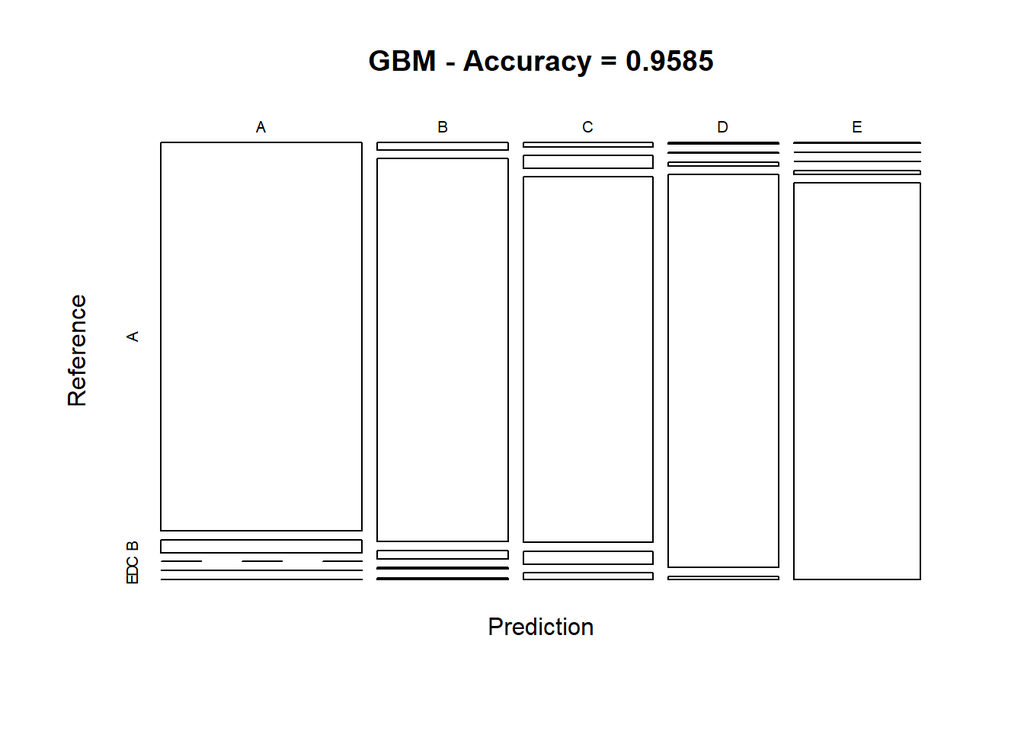

```r
plot(confMatGBM$table, col = confMatGBM$byClass,
     main = paste("GBM - Accuracy =", round(confMatGBM$overall['Accuracy'], 4)))
```

## Conclusion

Compairing results of Random Forests and GBM, Random Forests’ result is better. So I chose this model to predict testing.

```r
predictTEST <- predict(modFitRandForest, newdata=testing)
predictTEST
```

```
##  [1] B A B A A E D B A A B C B A E E A B B B
## Levels: A B C D E
```